# Peptidyl-prolyl cis-trans isomerase…

## Figure 4: Best-cluster predicted contact maps over the two true folds.

Predicted contact maps (MSA-Transformer) for the clusters best matching each fold, over the true contacts of fold 1 (upper triangle) and fold 2 (lower). Divergent contacts between clusters are the contact-level signature of fold-switching.

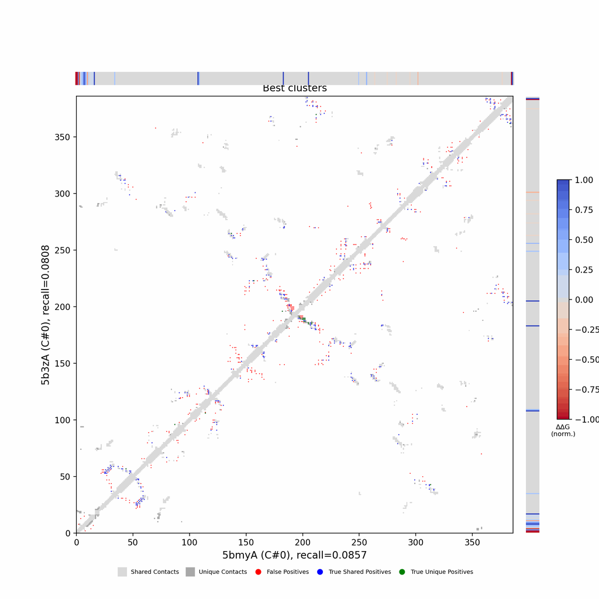

## Figure 5: Per-residue ΔΔG fold-preference contribution

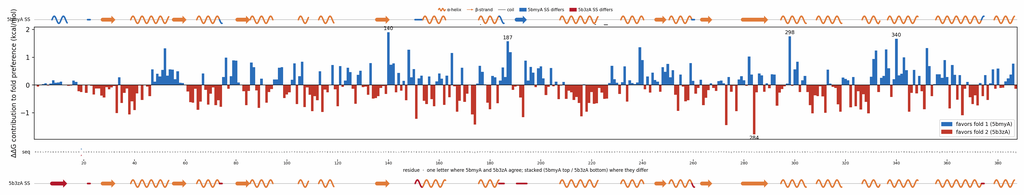

**More figures**

## Figure 6: Deep-MSA contact map panel / Best clusters contact map panel

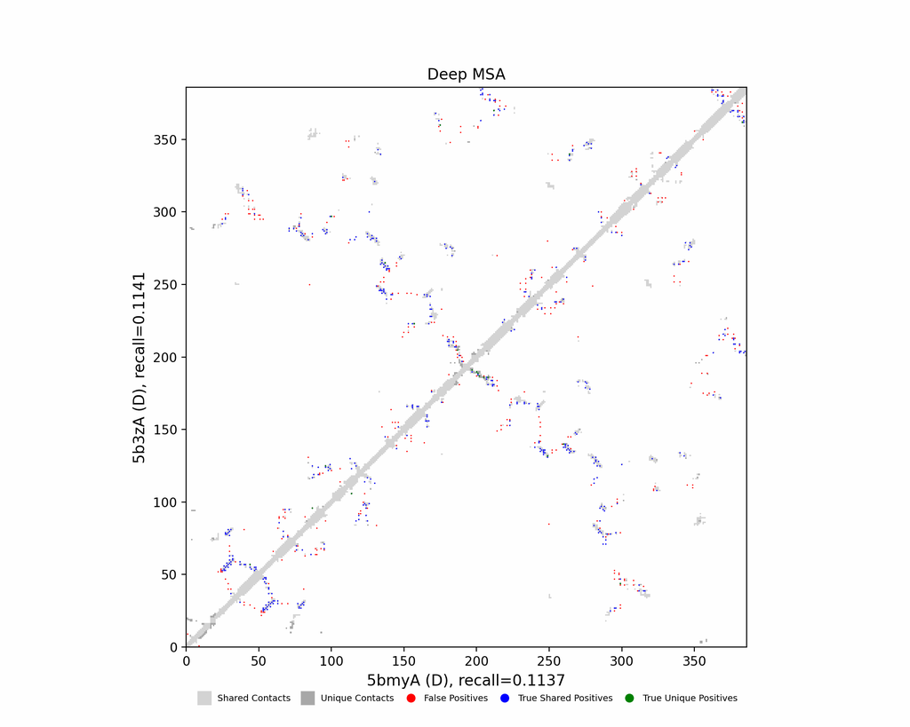

Deep-MSA contact map panel

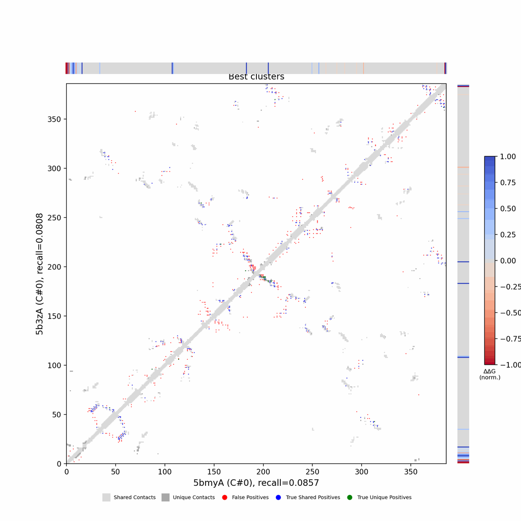

Best clusters contact map panel

## Figure 7: All clusters contact-map mosaic (small multiples).

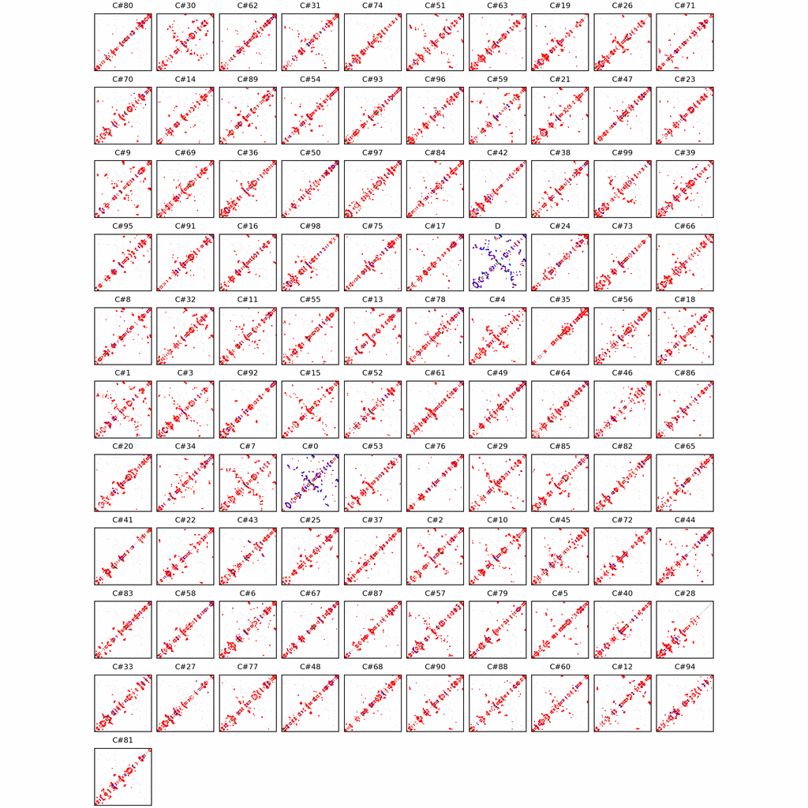

## Figure 8: Phylo null: tree with shuffled cluster fold labels.

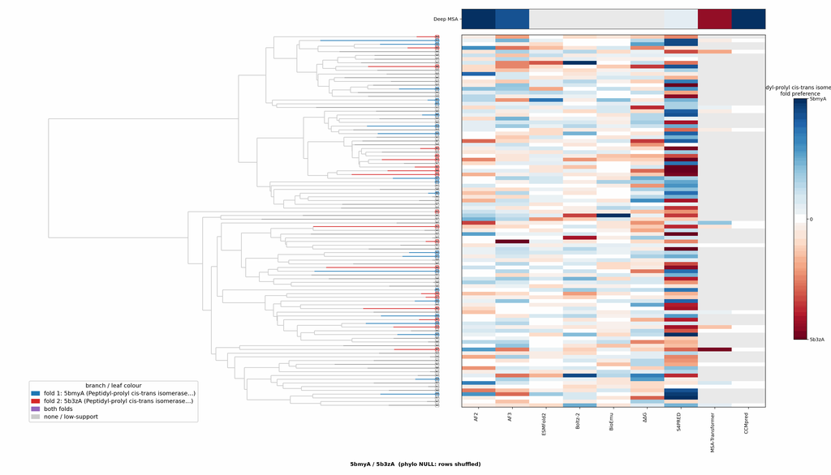

## Cluster metrics table

Per-cluster metrics underlying the figures above.

| cluster | n | neff | AF2_TM1 | AF2_TM2 | AF3_TM1 | AF3_TM2 | RE-MSAT-COM | RE-MSAT1 | RE-MSAT2 | ESM_SEQIDS | ESM_TM1 | ESM_TM2 | ΔΔG_Bias | ΔΔG_Bias_std | ΔΔG_frac_F1 | Boltz2_pref | S4PRED_pref | CCMpred_pref | BioEmu_pref |
| --- | --- | --- | --- | --- | --- | --- | --- | --- | --- | --- | --- | --- | --- | --- | --- | --- | --- | --- | --- |
| Deep | - | - | 0.94 | 0.88 | 0.94 | 0.89 | 0.44 | 0.43 | 0.45 | - | - | - | - | - | - | - | 0.0 | 0.0 | - |
| 000 | 329.0 | 80.0 | 0.26 | 0.26 | 0.26 | 0.26 | 0.24 | 0.25 | 0.22 | 001; 001; 007; 007; 008; 008; 004; 004; 002; 002 | 0.83 ± 0.02 | 0.80 ± 0.02 | -1.46 | 8.92 | 0.3 | 0.06 | 0.01 | 0.0 | 0.0 |
| 001 | 182.0 | 70.0 | 0.28 | 0.28 | 0.61 | 0.59 | 0.02 | 0.01 | 0.02 | 001; 001; 005; 007; 007; 005; 002; 002; 003; 003 | 0.84 ± 0.02 | 0.80 ± 0.02 | -1.57 | 2.89 | 0.2 | 0.02 | 0.0 | 0.0 | 0.01 |
| 002 | 157.0 | 71.0 | 0.22 | 0.21 | 0.32 | 0.31 | 0.01 | 0.02 | 0.02 | 001; 001; 002; 002; 008; 008; 009; 009; 003; 003 | 0.89 ± 0.02 | 0.85 ± 0.01 | 0.27 | 7.45 | 0.4 | 0.01 | -0.01 | 0.0 | -0.0 |
| 003 | 157.0 | 112.0 | 0.87 | 0.83 | 0.81 | 0.78 | 0.02 | 0.02 | 0.02 | 001; 001; 009; 009; 002; 005; 005; 002; 006; 006 | 0.84 ± 0.02 | 0.80 ± 0.01 | -3.69 | 4.48 | 0.1 | 0.01 | -0.0 | 0.0 | 0.01 |
| 004 | 154.0 | 75.0 | 0.26 | 0.27 | 0.3 | 0.29 | 0.0 | 0.0 | 0.01 | 004; 004; 003; 003; 002; 002; 001; 001; 008; 008 | 0.83 ± 0.01 | 0.80 ± 0.01 | -0.58 | 6.68 | 0.4 | 0.02 | 0.0 | 0.0 | 0.0 |
| 005 | 151.0 | 20.0 | 0.21 | 0.25 | 0.26 | 0.25 | 0.0 | 0.0 | 0.0 | 001; 001; 003; 003; 002; 002; 005; 005; 004; 004 | 0.89 ± 0.03 | 0.85 ± 0.03 | -6.23 | 3.69 | 0.1 | 0.01 | 0.0 | 0.0 | 0.0 |
| 006 | 147.0 | 39.0 | 0.31 | 0.3 | 0.8 | 0.78 | 0.01 | 0.02 | 0.01 | 001; 001; 005; 005; 003; 002; 002; 003; 006; 006 | 0.83 ± 0.03 | 0.80 ± 0.02 | 0.25 | 5.71 | 0.5 | 0.03 | -0.01 | 0.0 | 0.0 |
| 007 | 144.0 | 96.0 | 0.85 | 0.81 | 0.82 | 0.83 | 0.02 | 0.02 | 0.02 | 002; 005; 005; 002; 003; 004; 007; 007; 004; 003 | 0.83 ± 0.01 | 0.79 ± 0.01 | -4.17 | 8.56 | 0.2 | 0.0 | -0.01 | 0.0 | 0.02 |
| 008 | 139.0 | 15.0 | 0.26 | 0.26 | 0.84 | 0.8 | 0.0 | 0.0 | 0.0 | 009; 009; 010; 010; 003; 003; 002; 002; 001; 001 | 0.84 ± 0.02 | 0.80 ± 0.02 | -1.59 | 2.99 | 0.3 | 0.05 | -0.01 | 0.0 | -0.0 |
| 009 | 137.0 | 52.0 | 0.29 | 0.27 | 0.58 | 0.57 | 0.0 | 0.0 | 0.0 | 002; 002; 001; 001; 008; 008; 003; 003; 004; 004 | 0.84 ± 0.02 | 0.80 ± 0.02 | -3.88 | 4.62 | 0.1 | 0.01 | 0.01 | 0.0 | 0.01 |
| 010 | 132.0 | 36.0 | 0.28 | 0.26 | 0.38 | 0.36 | 0.0 | 0.0 | 0.0 | 001; 001; 008; 008; 004; 004; 007; 007; 006; 006 | 0.86 ± 0.04 | 0.82 ± 0.03 | -2.84 | 5.87 | 0.4 | 0.01 | -0.01 | 0.0 | 0.0 |
| 011 | 120.0 | 41.0 | 0.27 | 0.27 | 0.63 | 0.62 | 0.0 | 0.0 | 0.01 | 001; 001; 003; 009; 009; 003; 004; 004; 005; 005 | 0.86 ± 0.04 | 0.83 ± 0.03 | -3.67 | 3.46 | 0.3 | 0.01 | 0.0 | 0.0 | 0.0 |
| 012 | 115.0 | 43.0 | 0.27 | 0.27 | 0.34 | 0.34 | 0.01 | 0.01 | 0.01 | 001; 001; 003; 008; 008; 003; 002; 002; 009; 009 | 0.82 ± 0.02 | 0.79 ± 0.02 | -4.37 | 3.49 | 0.0 | 0.02 | -0.01 | 0.0 | 0.0 |
| 013 | 108.0 | 39.0 | 0.26 | 0.25 | 0.82 | 0.78 | 0.01 | 0.01 | 0.01 | 001; 001; 002; 002; 006; 003; 003; 006; 004; 004 | 0.84 ± 0.02 | 0.81 ± 0.02 | 0.49 | 6.59 | 0.4 | 0.02 | 0.01 | 0.0 | 0.01 |
| 014 | 107.0 | 43.0 | 0.3 | 0.29 | 0.51 | 0.49 | 0.0 | 0.0 | 0.0 | 008; 008; 009; 009; 001; 001; 010; 010; 007; 002 | 0.84 ± 0.02 | 0.80 ± 0.02 | -2.21 | 9.25 | 0.1 | 0.02 | -0.01 | 0.0 | 0.0 |
| 015 | 102.0 | 30.0 | 0.27 | 0.27 | 0.8 | 0.78 | 0.0 | 0.0 | 0.0 | 001; 001; 006; 006; 003; 002; 003; 002; 007; 007 | 0.89 ± 0.02 | 0.85 ± 0.01 | -8.89 | 4.26 | 0.1 | 0.03 | 0.0 | 0.0 | 0.01 |
| 016 | 100.0 | 30.0 | 0.26 | 0.25 | 0.38 | 0.37 | 0.01 | 0.01 | 0.03 | - | - | - | -3.35 | 6.81 | 0.3 | 0.06 | 0.01 | - | 0.01 |
| 017 | 99.0 | 24.0 | 0.25 | 0.25 | 0.64 | 0.63 | 0.0 | 0.0 | 0.0 | - | - | - | -7.38 | 5.69 | 0.1 | 0.04 | 0.02 | - | 0.0 |
| 018 | 96.0 | 48.0 | 0.28 | 0.26 | 0.84 | 0.81 | 0.0 | 0.0 | 0.01 | - | - | - | -1.52 | 5.45 | 0.3 | 0.02 | 0.0 | - | 0.01 |
| 019 | 94.0 | 22.0 | 0.36 | 0.35 | 0.71 | 0.68 | 0.01 | 0.01 | 0.01 | - | - | - | 2.79 | 6.88 | 0.6 | 0.02 | -0.0 | - | 0.0 |
| 020 | 90.0 | 38.0 | 0.22 | 0.21 | 0.21 | 0.21 | 0.02 | 0.02 | 0.03 | - | - | - | -0.16 | 5.97 | 0.4 | 0.01 | -0.01 | - | 0.01 |
| 021 | 90.0 | 31.0 | 0.24 | 0.23 | 0.5 | 0.48 | 0.01 | 0.01 | 0.01 | - | - | - | -1.32 | 6.06 | 0.4 | 0.03 | 0.0 | - | 0.01 |
| 022 | 89.0 | 16.0 | 0.28 | 0.28 | 0.24 | 0.24 | 0.0 | 0.0 | 0.01 | - | - | - | -4.31 | 2.84 | 0.1 | 0.02 | 0.01 | - | 0.0 |
| 023 | 86.0 | 37.0 | 0.24 | 0.24 | 0.29 | 0.28 | 0.0 | 0.0 | 0.0 | - | - | - | -1.91 | 3.34 | 0.4 | 0.02 | 0.0 | - | 0.01 |
| 024 | 84.0 | 12.0 | 0.25 | 0.24 | 0.5 | 0.49 | 0.01 | 0.01 | 0.01 | - | - | - | -1.21 | 6.69 | 0.4 | 0.0 | 0.0 | - | 0.01 |
| 025 | 84.0 | 27.0 | 0.52 | 0.51 | 0.88 | 0.84 | 0.0 | 0.0 | 0.0 | - | - | - | -2.05 | 4.63 | 0.3 | 0.03 | -0.02 | - | 0.01 |
| 026 | 84.0 | 39.0 | 0.22 | 0.23 | 0.72 | 0.72 | 0.0 | 0.01 | 0.01 | - | - | - | -2.2 | 3.94 | 0.3 | 0.01 | -0.0 | - | 0.0 |
| 027 | 82.0 | 36.0 | 0.31 | 0.3 | 0.36 | 0.34 | 0.01 | 0.01 | 0.01 | - | - | - | -2.15 | 4.6 | 0.4 | 0.02 | 0.0 | - | 0.01 |
| 028 | 82.0 | 59.0 | 0.88 | 0.85 | 0.8 | 0.77 | 0.02 | 0.02 | 0.02 | - | - | - | -3.05 | 7.38 | 0.3 | 0.01 | 0.01 | - | 0.03 |

[output cut: 71 more lines]